# A 股 & 美股周报（自动生成）

基于真实数据 + AI 摘要

Author

Penny

Published

October 23, 2026

# 本周市场概览

|  | 指数 | 收盘价 | 显示 |
| --- | --- | --- | --- |
| 0 | 上证指数 | 3690.4750 | 下跌 0.69% |
| 1 | 深证成指 | 11673.8260 | 下跌 1.09% |
| 2 | 创业板指 | 2684.0970 | 下跌 3.18% |
| 3 | 标普500 | 7663.4302 | 下跌 1.21% |
| 4 | 纳斯达克 | 26008.8594 | 下跌 2.60% |

# 本周行业热点

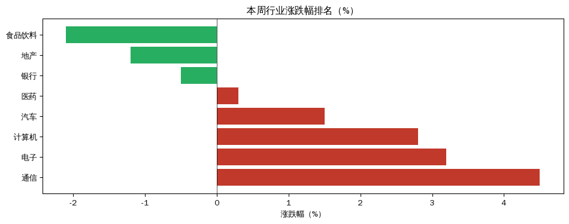

# AI 生成市场摘要

本周A股市场整体承压，主要指数全线收跌。上证指数报3690.48点，周跌0.69%；深证成指跌1.09%；创业板指表现最弱，跌幅达3.18%，成长板块调整压力显著。海外市场同步走弱，标普500跌1.21%，纳斯达克跌2.60%，全球风险偏好有所回落。

行业层面分化明显，科技主线逆势走强。通信板块以4.5%的涨幅领跑，电子、计算机分别上涨3.2%和2.8%，或受产业政策预期及算力基础设施投资加码提振，资金持续向科技成长方向集中。汽车板块涨1.5%，表现相对稳健。另一方面，食品饮料跌2.1%，地产、银行分别下跌1.2%和0.5%，消费与地产链延续弱势，反映内需修复预期仍待巩固。

展望下周，需重点关注三方面因素：一是国内宏观经济数据及政策定调对市场情绪的牵引；二是海外科技股调整是否延续，及其对A股相关板块的传导效应；三是创业板指大幅回调后，成长板块能否企稳。整体来看，市场结构性特征突出，科技主线与传统板块的分化格局短期或延续，建议关注业绩确定性强、政策催化明确的领域。